# Yeast cis-eQTL barcode mapping final report

Kimberly Insigne

Friday, April 24, 2015

## Overview

Goal: Determine which barcodes are suitable for downstream analysis of RNA-seq.

Ideally we want barcodes that:

- match to a perfect reference sequence (no synthesis errors)
- have enough coverage
- and only map to one variant (or a group of very close sequences).

Reference oligo structure:

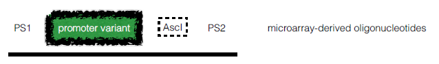

Read structure:

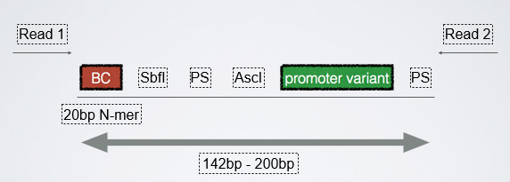

**Important**: The reads are a reverse complement of the sequences in the reference file.

### Barcode mapping general statistics

Overview of dataset:

- Total number of oligos: 45,623
  - 6,000 control (5,923 unique)
  - 8,986 lib2-firstAUG (8,975 unique)
  - 6,271 lib3-firstUTR
  - lib4 not performed

Number of reads: 25,748,575  
Number of reads that perfectly matched reference: 39%

| statistic | control | lib2-firstAUG | lib3-firstUTR |
| --- | --- | --- | --- |
| Number of barcodes | 114,931 | 205,704 | 140,190 |
| Number of barcodes >= 3 | 85,588 | 170,690 | 110,354 |
| Number of final barcodes | 79,412 | 168,811 | 108,186 |
| % of potential barcodes kept | 92.7% | 98.9% | 98.0% |
| % reference covered | 5635/5923 = 95.1% | 8781/8975 = 97.8% | 6071/6271 = 96.8% |
| Median number of barcodes per variant | 12 | 18 | 17 |
| Median number of reads per final barcode | 24 | 19 | 29 |

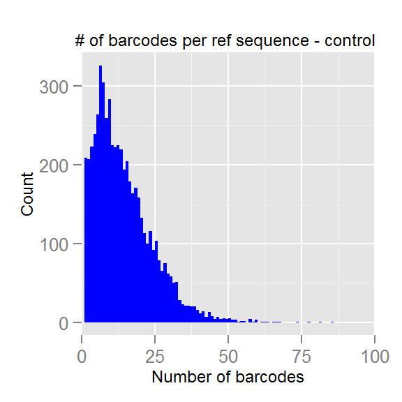

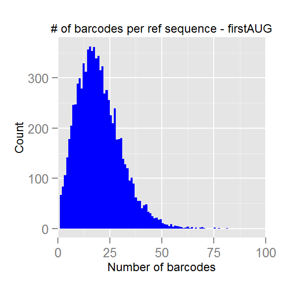

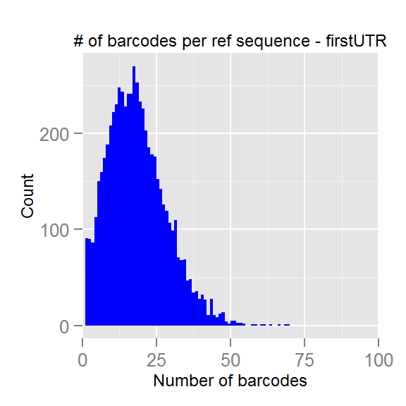

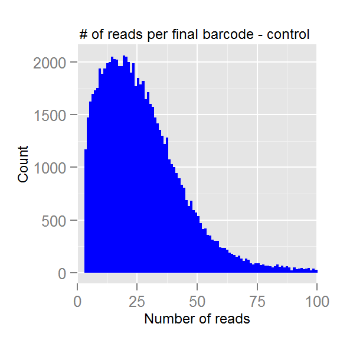

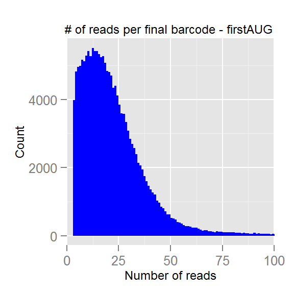

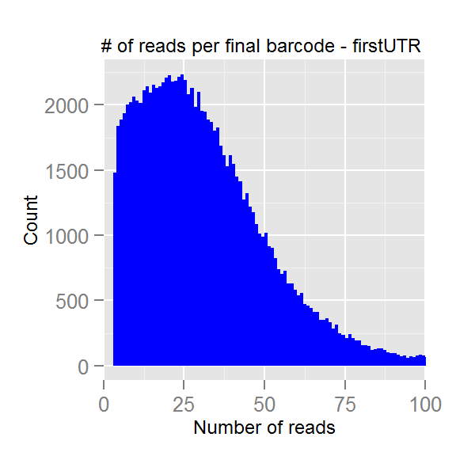

### Running the analysis ###

All the analysis described below is automatically performed by `barcodes_for_RNA_seq.py`. This script takes in four arguments: `<reads_file> <reference_file> <library> <output>`.

- `<reads_file>`: FASTQ file containing all reads from all libraries that have already been processed with PEAR.
- `<reference_file>`: CSV that contains the reference sequences. The first field must be the name of the sequence and the second field must contain the sequence.
- `<library>`: The name of the library to be analyzed. These must match the names in the first field of the CSV file. Valid arguments in this study are: all, sharon, firstTile-AUG, firstTileUTR (sharon is the name of the control library)
- `<output>`: Output file name. The script outputs a list of the final barcodes.

Example usage: `python barcodes_for_RNA_seq.py master_reads.fastq tiledDesign4order_141101_noNBases.csv sharon control_final_barcodes.txt`

### Workflow:

The paired-end reads must first be merged together with PEAR. Files denoted R1 are forward reads and R2 are reverse reads. Additional arguments: `-m 220 -n 100 -j 30` (max size = 220, min size = 100, 30 processors). Next, the assembled reads files from all libraries are concatenated into one master file which is used as input by the analysis script.

The script described above performs the following analysis:

- Only keep reads that perfectly match a reference sequence (won’t catch synthesis errors).
- Of those barcodes that map to a reference sequence, only keep barcodes that appear at least 3 times. This gets rid of any sequencing errors that may be in the barcodes. Call these potential barcodes.
- From the set of **all** reads, map variants to potential barcodes.
- For each barcode:
  - Assign the most common read as the reference. Calculate the Levenshtein distance between the reference and all other variants that map to this barcode.
  - If the max Levenshtein distance >= 11 (this threshold determined by bootstrapping, explained below), throw out this barcode.

**Determining cutoff for Levenshtein distance**  
Randomly select two reference sequences (with replacement) and calculate the distance. Do this 100,000 times to form a reference Levenshtein distance distribution. Take the 1% percentile as the cutoff threshold.

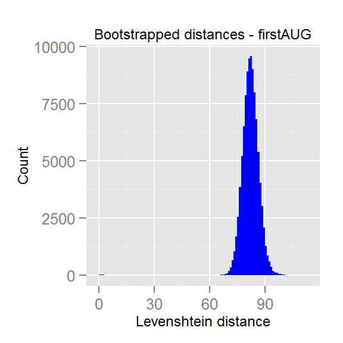

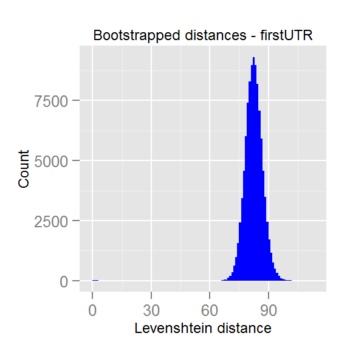

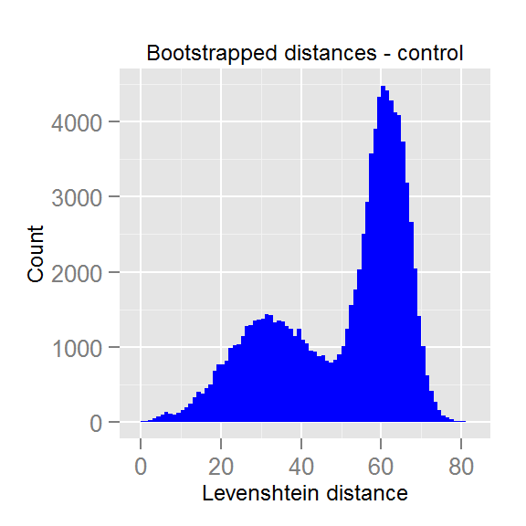

**Conclusion**: For the control, firstAUG and firstUTR libraries the 1% percentile is 11, 72, and 72. Based on these bootstrap distributions, take cutoff = 11.